# bpred

### branch prediction

- guess where jumps, etc. go
- very important for out-of-order processor performance
  - takes many cycles before misprediction detected
  - takes some time to undo misprediction
  - lots of instructions per cycle “missed” on misprediction
- modern laptop/desktop CPUs devote a lot of space to branch prediction

### static branch prediction

- forward (target $>$ PC) not taken; backward taken
- intuition: loops:

```
LOOP: ...
      ...
      je LOOP

LOOP: ...
      jne SKIP_LOOP
      ...
      jmp LOOP
SKIP_LOOP:
```

### exercise: static prediction

```
.global foo
foo:
    xor %eax, %eax // eax <- 0
foo_loop_top:
    test $0x1, %edi
    je foo_loop_bottom  // if (edi & 1 == 0) goto for_loop_bottom
    add %edi, %eax
foo_loop_bottom:
    dec %edi            // edi = edi - 1
    jg for_loop_top // if (edi > 0) goto for_loop_top
    ret
```

- suppose %edi = 3 (initially)
- and using forward-not-taken, backwards-taken strategy:
- how many mispreditions for je? for jg?

### predict: repeat last

[figure not shown]

### example

[figure not shown]

### collisions?

- two branches could have same hashed PC
- nothing in table tells us about this
  - versus direct-mapped cache: had *tag bits* to tell
- is it worth it?
- adding tag bits makes table *much* larger and/or slower
- but does anything go wrong when there’s a collision?

### collision results

- possibility 1: both branches usually taken
  - no actual conflict — prediction is better(!)
- possibility 2: both branches usually not taken
  - no actual conflict — prediction is better(!)
- possibility 3: one branch taken, one not taken
  - performance probably worse

### 1-bit predictor and loops

- loops have jump at beginning/end
  - static prediction got these 100%
- 1-bit prediction: predicts first and last iteration wrong
  - first wrong: last time loop ran, did not continue, but should
  - last wrong: last time loop ran, did continue, but should not
- everything else correct

### exercise (pt 1)

- use 1-bit predictor on this loop
  - executed in outer loop (not shown) many, many times
- what is the conditional jump misprediction rate for `i % 3 == 0`? for `i == 50`? overall?

```c
int i = 0;
while (true) {
  if (i % 3 == 0)
    goto next;
  ...
next:
  i += 1;
  if (i == 50)
    break;
}
```

| i= | branch | pred | outcome | correct? |
| --- | --- | --- | --- | --- |
| 0 | mod 3 | ??? | T | ??? |
| 1 | == 50 | ??? | F | ??? |
| 1 | mod 3 | T | F | — |
| 2 | == 50 | F | F | $\checkmark$ |
| … | … | … | … | … |

### exercise soln (1)

[figure not shown]

### beyond 1-bit predictor

- devote *more space* to storing history
- main goal: *rare exceptions don’t immediately change prediction*
- example: branch taken 99% of the time
- 1-bit predictor: wrong about 2% of the time
  - 1% when branch not taken
  - 1% of taken branches right after branch not taken
- new predictor: wrong about 1% of the time
  - 1% when branch not taken

### 2-bit saturating counter

[figure not shown]

### example

[figure not shown]

### generalizing saturating counters

- 2-bit counter: ignore one exception to taken/not taken
- 3-bit counter: ignore more exceptions
- `000`$\;\leftrightarrow\;$`001`$\;\leftrightarrow\;$`010`$\;\leftrightarrow\;$`011`$\;\leftrightarrow\;$`100`$\;\leftrightarrow\;$`101`$\;\leftrightarrow\;$`110`$\;\leftrightarrow\;$`111`
- `000`-`011`: not taken
- `100`-`111`: taken

### exercise

- use 2-bit predictor on this loop
  - executed in outer loop (not shown) many, many times
- what is the conditional branch misprediction rate?

```c
int i = 0;
while (true) {
  if (i % 3 == 0) goto next;
  ...
next:
  i += 1;
  if (i == 50) break;
}
```

### exercise soln (1)

[figure not shown]

### briefly: other prediction ideas

- branches often have cyclic behavior
  - example: `for (int i = 0; i < 5; ++i)`
  - example: `if (first or last item) {...}`
  - prediction idea: try to find/count fixed loops
  - prediction idea: identify patterns like TTNNNTTNNNT$\rightarrow$T
- branches are correlated
  - example: flag checked in multiple places
  - example: special case for first iteration of loop
  - prediction idea: identify patterns across multiple branches

### predicting ret: ministack of return addresses

- predicting ret — ministack in processor registers
  - push on ministack on call; pop on ret
- ministack overflows? discard oldest, mispredict it later

[figure not shown]

### 4-entry return address stack

[figure not shown]

- on `call`: increment index, save return address in that slot
- on `ret`: read prediction from index, decrement index

### branch prediction before fetch/decode

[figure not shown]

### branch target buffer

- suppose we have OOO processor that fetches 4 instructions/cycle
- given `jmp LABEL` is 1st instruction we fetch
  - want to fetch code at LABEL *ideally in same cycle* to avoid slowdown
  - if not same cycle, in next cycle
  - likely we won’t decode `LABEL` for several cycles
- if it’s `jle LABEL` instead…
  - also want to predict if it will go to LABEL just as fast
  - may not figure out its a jle for several cycles
- solution: special predictor for what instruction will be

### BTB: cache for branch targets

[figure not shown]

### indirect branch prediction

- `jmp *%rax` or `jmp *(%rax, %rcx, 8)` or `call *%rax` or …
  - example: implementing switch statement
  - example: implementing polymorphic method call
- want to predict *target address*
- BTB could store one possibility
- really want to take advantage of context
  - example: guess whether we’ll call Rectangle.GetArea or Circle.GetArea
- prediction idea: instead of tables containing taken/not taken…
- … have table containing predicted target
  - one implementation: hashtable keyed by recent branches taken

### branch patterns

```
i = 4;
do {
    ...
    i -= 1;
} while (i != 0);
```

- typical pattern for jump to top of do-while above:
- `(T = taken, N = not taken)`
- goal: take advantage of recent pattern to make predictions
- just saw ‘NTTTNT’? predict T next
- ‘TNTTTN’? predict T; ‘TTNTTT’? predict N next
- …

### local pattern predictor (incomplete)

[figure not shown]

### recent pattern to prediction?

- easy cases:
- just saw TTTTTT: predict T
- just saw NNNNNN: predict N
- just saw TNTNTN: predict T
- hard cases:
- TTNTTTT
  - predict T? loop with many iterations (NTTTTTTTNTTTTTTTNTTTTTT…)
  - predict T? if statement mostly taken (TTTTNTTNTTTTTTTTTTNTTTT…)
  - predict N? loop with 5 iterations (NTTTTNTTTTNTTTTNTTTTNTT…)
- (many more)

### history of history

[figure not shown]

### local patterns and collisions (1)

```
i = 10000;
do {
    p = malloc(...);
    if (p == NULL) goto error;  // BRANCH 1
    ...
} while (i-- != 0); // BRANCH 2
```

- what if branch 1 and branch 2 hash to same table entry?
- pattern: TNTNTNTNTNTNTNTNT…
- actually no problem to predict!

### local patterns and collisions (2)

```
i = 10000;
do {
    if (i % 2 == 0) goto skip; // BRANCH 1
    ...
    p = malloc(...);
    if (p == NULL) goto error;  // BRANCH 2
skip: ...
} while (i-- != 0); // BRANCH 3
```

- what if branch 1 and branch 2 and branch 3 hash to same table entry?
- pattern: TTNNTTNNTTNNTTNNTT
- also no problem to predict!

### local patterns and collisions (3)

```
i = 10000;
do {
    if (A) goto one  // BRANCH 1
    ...
one:
    if (B) goto two  // BRANCH 2
    ...
two:
    if (A or B) goto three // BRANCH 3
    ...
    if (A and B) goto three // BRANCH 4
    ...
three:
    ... // changes A, B
} while (i-- != 0);
```

- what if branch 1-4 hash to same table entry?
- *better for prediction of branch 3 and 4*

### global history predictor: idea

- one predictor idea: ignore the PC
- just record taken/not-taken pattern for all branches
- lookup in big table like for local patterns

### global history predictor (1)

[figure not shown]

### correlating predictor

- global history *and* local info good together
- one idea: *combine history register + PC* (‘‘gshare’’)

[figure not shown]

### mixing predictors

- different predictors good at different times
- one idea: have two predictors, + predictor to predict which is right

[figure not shown]

### loop count predictors (1)

```
for (int i = 0; i < 64; ++i)
    ...
```

- can we predict this perfectly with predictors we’ve seen
- yes — local or global history with 64 entries
- but this is very important — more efficient way?

### loop count predictors (2)

- loop count predictor idea: look for NNNNNNT+repeat (or TTTTTTN+repeat)
- track for each possible loop branch:
  - how many repeated Ns (or Ts) so far
  - how many repeated Ns (or Ts) last time before one T (or N)
  - something to indicate this pattern is useful?
- known to be used on Intel

### benchmark results

- from 1993 paper
- (not representative of modern workloads?)
- rate for conditional branches on benchmark
- variable table sizes

### 2-bit ctr + local history

from McFarling, ‘‘Combining Branch Predictors’’ (1993)

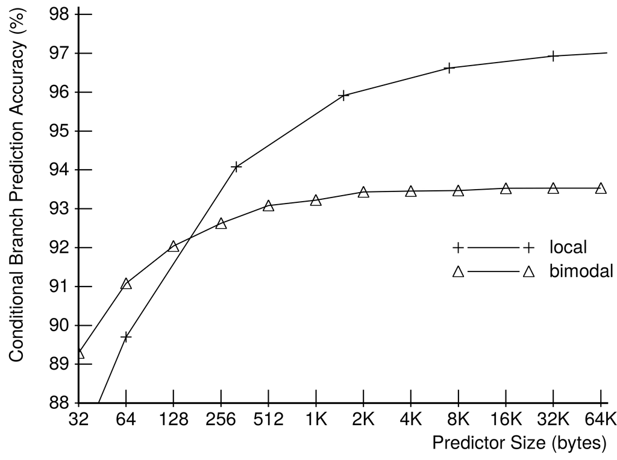

### 2-bit (bimodal) + local + global hist

from McFarling, ‘‘Combining Branch Predictors’’ (1993)

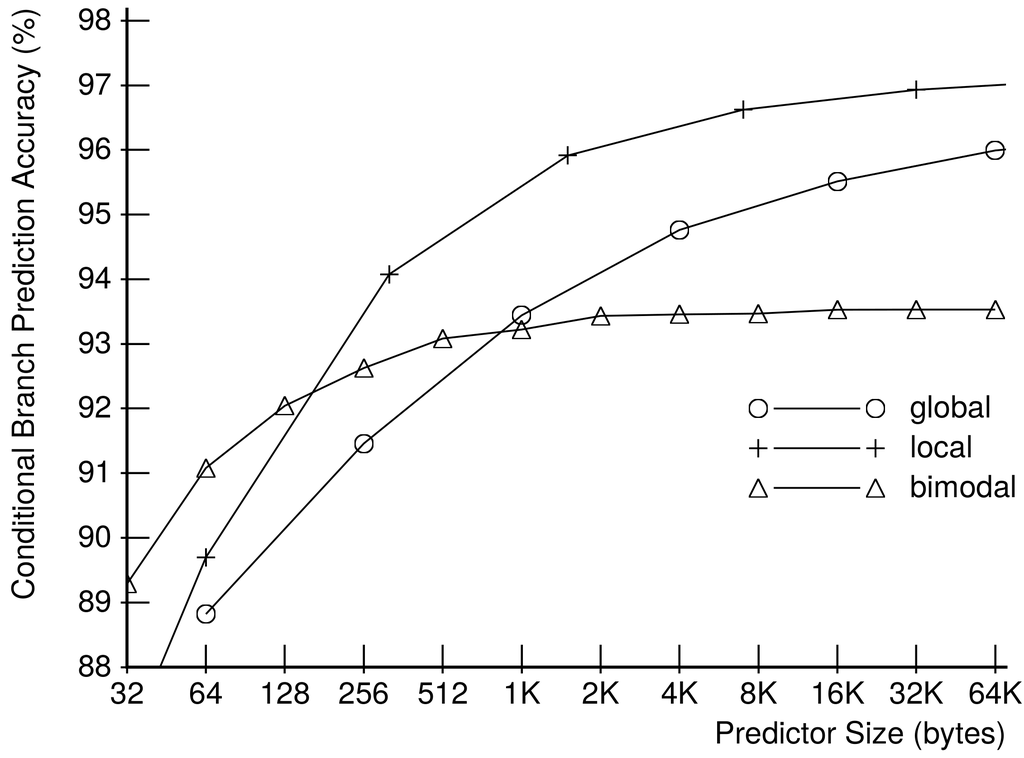

### global + hash(global+PC) (gshare/gselect)

from McFarling, ‘‘Combining Branch Predictors’’ (1993)

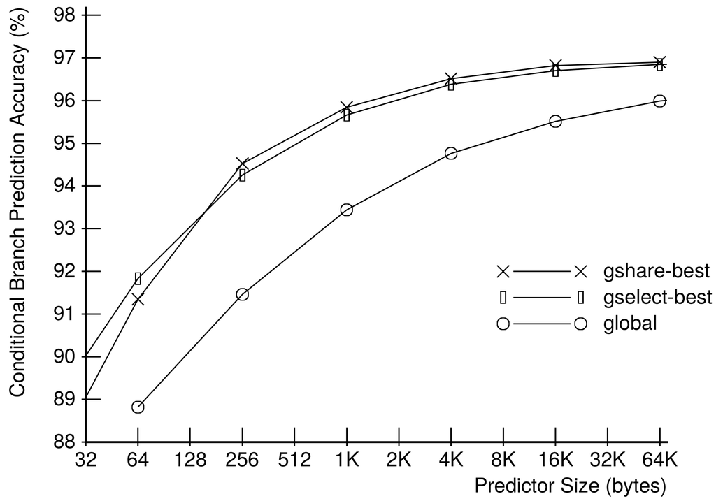

### real BP?

- details of modern CPU’s branch predictors often not public
- but…
- Google Project Zero blog post with reverse engineered details
- https://googleprojectzero.blogspot.com/2018/01/reading-privileged-memory-with-side.html
- for RE’d BTB size:
- https://xania.org/201602/haswell-and-ivy-btb

### reverse engineering Haswell BPs

- branch target buffer
  - 4-way, 4096 entries
  - ignores bottom 4 bits of PC?
  - hashes PC to index by shifting + XOR
  - seems to store 32 bit offset from PC (not all 48+ bits of virtual addr)
- indirect branch predictor
  - like the global history + PC predictor we showed, but…
  - uses history of recent branch addresses instead of taken/not taken
  - keeps some info about last 29 branches
- what about conditional branches??? loops???
  - couldn’t find a reasonable source